# TD4 ML - Credit scoring

Thomas & Bernie

17/09/2020

# 1 Introduction

Les institutions financières subissent des pertes importantes en raison du défaut de prêts automobiles. Cela a conduit à un resserrement de la souscription de crédits automobiles et à une augmentation des taux de rejet de crédits automobiles. La nécessité d’un meilleur modèle de notation du risque de crédit est par conséquent soulevé par la directions de l’institutions “SuperCar4Everyone”. Cela justifie une étude pour estimer les drivers ou variables prédictrices du défaut de crédit automobile.

“SuperCar4Everyone” vous a donc embauché pour prédire avec précision la probabilité de défaut de l’emprunteur sur un prêt de véhicule dans le premier EMI (Equated Monthly Installment). l’EMI correspond à est un montant de paiement fixe effectué par un emprunteur à un prêteur à une date précise chaque mois civil. Des versements mensuels égaux sont utilisés pour rembourser les intérêts et le principal chaque mois, de sorte que sur un certain nombre d’années, le prêt soit remboursé intégralement.

Les informations suivantes concernant le prêt et le prêteur sont fournies:

- Informations sur le prêteur (données démographiques telles que l’âge, le revenu, la preuve d’identité, etc.)
- Informations sur le prêt (détails du décaissement, montant, IME, ratio prêt / valeur, etc.)
- Données et historique du bureau (score du bureau, nombre de comptes actifs, statut des autres prêts, historique de crédit, etc.)

Cela garantira que les clients capables de rembourser ne seront pas rejetés et que des critères discriminants pourront être identifiés et pourront être utilisés par “SuperCar4Everyone” pour minimiser les taux de défaut.

# 2 Les librairies utiles & les données

## 2.1 Les librairies

```r
# load useful libraries
library(tidyverse)
library(dplyr)
library(knitr)
library(skimr)
library(lubridate)
library(gridExtra)
library(scorecard)
library(ggplot2)
library(ggplotify)
library(plotly)
library(questionr)
library(caret)
library(pROC)
library(purrr)
```

## 2.2 Les Datas

L’entreprise « SuperCar4Everyone » malgré leur système de données logé dans le cloud, nous met à disposition la forme la plus évoluée de stockage de données : le CSV. Ce fichier contient un certain nombre de d’informations et un expert métier est là pour répondre à vos questions.

Contenu du fichier CSV:

- Primary accounts are those which the customer has taken for his personal use
- Secondary accounts are those which the customer act as a co-applicant or gaurantor

| Variable Name | Description |
| --- | --- |
| Aadhar_flag | if aadhar (Unique Identification Authority) was shared by the customer then flagged as 1 |
| asset_cost | Cost of the Asset |
| AVERAGE.ACCT.AGE | Average loan tenure |
| branch_id | Branch where the loan was disbursed |
| CREDIT.HISTORY.LENGTH | Time since first loan |
| Current_pincode | Current pincode of the customer |
| Date.of.Birth | Date of birth of the customer |
| DELINQUENT.ACCTS.IN.LAST.SIX.MONTHS | Loans defaulted in the last 6 months |
| DisbursalDate | Date of disbursement |
| disbursed_amount | Amount of Loan disbursed |
| Driving_flag | if DL was shared by the customer then flagged as 1 |
| Employee_code_ID | Employee of the organization who logged the disbursement |
| Employment.Type | Employment Type of the customer (Salaried/Self Employed) |
| loan_default | Payment default in the first EMI on due date |
| ltv | Loan to Value of the asset |
| manufacturer_id | Vehicle manufacturer(Hero, Honda, TVS etc.) |
| MobileNo_Avl_Flag | if Mobile no. was shared by the customer then flagged as 1 |
| NEW.ACCTS.IN.LAST.SIX.MONTHS | New loans taken by the customer in last 6 months before the disbursment |
| NO.OF_INQUIRIES | Enquries done by the customer for loans |
| PAN_flag | if pan (permanent account number) was shared by the customer then flagged as 1 |
| Passport_flag | if passport was shared by the customer then flagged as 1 |
| PERFORM_CNS.SCORE | Bureau Score |
| PERFORM_CNS.SCORE.DESCRIPTION | Bureau score description |
| PRI.ACTIVE.ACCTS | count of active loans taken by the customer at the time of disbursement |
| PRI.CURRENT.BALANCE | total Principal outstanding amount of the active loans at the time of disbursement |
| PRI.DISBURSED.AMOUNT | total amount that was disbursed for all the loans at the time of disbursement |
| PRI.NO.OF.ACCTS | count of total loans taken by the customer at the time of disbursement |
| PRI.OVERDUE.ACCTS | count of default accounts at the time of disbursement |
| PRI.SANCTIONED.AMOUNT | total amount that was sanctioned for all the loans at the time of disbursement |
| PRIMARY.INSTAL.AMT | EMI Amount of the primary loan |
| State_ID | State of disbursement |
| supplier_id | Vehicle Dealer where the loan was disbursed |
| UniqueID | Identifier for customers |
| VoterID_flag | if voter was shared by the customer then flagged as 1 |

# 3 Le snorkeling

### 3.0.1 Chargement des fichiers et premières impressions

Data summary

| Name | datainput |
| --- | --- |
| Number of rows | 1310 |
| Number of columns | 34 |
| _______________________ |  |
| Column type frequency: |  |
| character | 6 |
| numeric | 28 |
| ________________________ |  |
| Group variables | None |

**Variable type: character**

| skim_variable | n_missing | complete_rate | min | max | empty | n_unique | whitespace |
| --- | --- | --- | --- | --- | --- | --- | --- |
| Date.of.Birth | 0 | 1.00 | 10 | 10 | 0 | 1015 | 0 |
| Employment.Type | 32 | 0.98 | 8 | 13 | 0 | 2 | 0 |
| DisbursalDate | 0 | 1.00 | 10 | 10 | 0 | 82 | 0 |
| PERFORM_CNS.SCORE.DESCRIPTION | 0 | 1.00 | 10 | 55 | 0 | 19 | 0 |
| AVERAGE.ACCT.AGE | 0 | 1.00 | 9 | 10 | 0 | 89 | 0 |
| CREDIT.HISTORY.LENGTH | 0 | 1.00 | 9 | 11 | 0 | 134 | 0 |

**Variable type: numeric**

| skim_variable | n_missing | complete_rate | mean | sd | p0 | p25 | p50 | p75 | p100 | hist |
| --- | --- | --- | --- | --- | --- | --- | --- | --- | --- | --- |
| UniqueID | 0 | 1 | 536524.88 | 68011.93 | 417614.00 | 478752.75 | 540456.50 | 593972.50 | 653991.00 | ▇▆▇▇▆ |
| disbursed_amount | 0 | 1 | 55411.33 | 15430.83 | 15579.00 | 47169.25 | 54516.00 | 61311.50 | 153318.00 | ▂▇▁▁▁ |
| asset_cost | 0 | 1 | 77078.74 | 22050.80 | 37000.00 | 65603.75 | 70346.00 | 79000.00 | 215528.00 | ▇▅▁▁▁ |
| ltv | 0 | 1 | 74.95 | 12.43 | 23.05 | 69.53 | 77.33 | 84.58 | 94.95 | ▁▁▂▇▆ |
| branch_id | 0 | 1 | 70.51 | 67.02 | 1.00 | 13.00 | 63.00 | 120.00 | 260.00 | ▇▅▃▁▁ |
| supplier_id | 0 | 1 | 19433.58 | 3516.75 | 12374.00 | 16264.00 | 18651.00 | 22949.50 | 24770.00 | ▃▅▃▃▇ |
| manufacturer_id | 0 | 1 | 69.99 | 21.61 | 45.00 | 48.00 | 86.00 | 86.00 | 145.00 | ▇▁▇▁▁ |
| Current_pincode_ID | 0 | 1 | 3225.40 | 2182.66 | 5.00 | 1508.00 | 2782.50 | 5208.75 | 7341.00 | ▇▇▅▃▆ |
| State_ID | 0 | 1 | 6.98 | 4.31 | 1.00 | 4.00 | 6.00 | 9.00 | 21.00 | ▇▆▂▁▁ |
| Employee_code_ID | 0 | 1 | 1519.00 | 974.94 | 3.00 | 720.00 | 1388.00 | 2260.75 | 3774.00 | ▇▇▆▅▂ |
| MobileNo_Avl_Flag | 0 | 1 | 1.00 | 0.00 | 1.00 | 1.00 | 1.00 | 1.00 | 1.00 | ▁▁▇▁▁ |
| Aadhar_flag | 0 | 1 | 0.84 | 0.37 | 0.00 | 1.00 | 1.00 | 1.00 | 1.00 | ▂▁▁▁▇ |
| PAN_flag | 0 | 1 | 0.08 | 0.28 | 0.00 | 0.00 | 0.00 | 0.00 | 1.00 | ▇▁▁▁▁ |
| VoterID_flag | 0 | 1 | 0.14 | 0.35 | 0.00 | 0.00 | 0.00 | 0.00 | 1.00 | ▇▁▁▁▁ |
| Driving_flag | 0 | 1 | 0.03 | 0.18 | 0.00 | 0.00 | 0.00 | 0.00 | 1.00 | ▇▁▁▁▁ |
| Passport_flag | 0 | 1 | 0.00 | 0.06 | 0.00 | 0.00 | 0.00 | 0.00 | 1.00 | ▇▁▁▁▁ |
| PERFORM_CNS.SCORE | 0 | 1 | 520.09 | 293.68 | 0.00 | 300.00 | 650.00 | 738.00 | 853.00 | ▃▂▁▅▇ |
| PRI.NO.OF.ACCTS | 0 | 1 | 4.45 | 6.10 | 0.00 | 1.00 | 2.00 | 6.00 | 104.00 | ▇▁▁▁▁ |
| PRI.ACTIVE.ACCTS | 0 | 1 | 1.95 | 2.41 | 0.00 | 1.00 | 1.00 | 3.00 | 24.00 | ▇▁▁▁▁ |
| PRI.OVERDUE.ACCTS | 0 | 1 | 0.27 | 0.66 | 0.00 | 0.00 | 0.00 | 0.00 | 8.00 | ▇▁▁▁▁ |
| PRI.CURRENT.BALANCE | 0 | 1 | 265683.58 | 785405.18 | -4826.00 | 0.00 | 26590.50 | 150735.50 | 10091566.00 | ▇▁▁▁▁ |
| PRI.SANCTIONED.AMOUNT | 0 | 1 | 333317.01 | 866399.90 | 0.00 | 0.00 | 52000.00 | 245470.75 | 10000000.00 | ▇▁▁▁▁ |
| PRI.DISBURSED.AMOUNT | 0 | 1 | 335509.78 | 886934.94 | 0.00 | 0.00 | 51041.00 | 247343.25 | 10000000.00 | ▇▁▁▁▁ |
| PRIMARY.INSTAL.AMT | 0 | 1 | 16338.40 | 145313.94 | 0.00 | 0.00 | 1447.00 | 6918.00 | 4189968.00 | ▇▁▁▁▁ |
| NEW.ACCTS.IN.LAST.SIX.MONTHS | 0 | 1 | 0.72 | 1.24 | 0.00 | 0.00 | 0.00 | 1.00 | 13.00 | ▇▁▁▁▁ |
| DELINQUENT.ACCTS.IN.LAST.SIX.MONTHS | 0 | 1 | 0.17 | 0.50 | 0.00 | 0.00 | 0.00 | 0.00 | 7.00 | ▇▁▁▁▁ |
| NO.OF_INQUIRIES | 0 | 1 | 0.32 | 0.92 | 0.00 | 0.00 | 0.00 | 0.00 | 13.00 | ▇▁▁▁▁ |
| loan_default | 0 | 1 | 0.28 | 0.45 | 0.00 | 0.00 | 0.00 | 1.00 | 1.00 | ▇▁▁▁▃ |

L’ appréhension de la data via la fonction ‘skim’ est déjà un bon début car il nous donne l’idée de la population des contrats à étudier 1310 et de l’interprétation des variables en ‘character’ ou ‘numeric’. Elle nous indique les valeurs manquantes et le poid de ces ‘n_missing’.

Le format de certaines variables nécessite d’être retravaillé, une rapide vue des variable permet de se faire une première idée :

| ltv | disbursed_amount | Date.of.Birth | supplier_id | Employment.Type | PERFORM_CNS.SCORE | PERFORM_CNS.SCORE.DESCRIPTION | loan_default | AVERAGE.ACCT.AGE | CREDIT.HISTORY.LENGTH |
| --- | --- | --- | --- | --- | --- | --- | --- | --- | --- |
| 80.94 | 153318 | 18/10/1978 | 23044 | Self employed | 647 | G-Low Risk | 0 | 2yrs 10mon | 5yrs 9mon |
| 68.67 | 143188 | 04/10/1985 | 14292 | Self employed | 688 | E-Low Risk | 1 | 1yrs 1mon | 4yrs 3mon |
| 69.79 | 131509 | 10/11/1984 | 23044 | Salaried | 15 | Not Scored: Sufficient History Not Available | 0 | 0yrs 0mon | 0yrs 0mon |
| 78.50 | 129598 | 06/10/1985 | 23127 | Self employed | 15 | Not Scored: Sufficient History Not Available | 1 | 1yrs 11mon | 3yrs 10mon |
| 75.15 | 129506 | 23/03/1983 | 20684 | Self employed | 571 | I-Medium Risk | 0 | 0yrs 5mon | 0yrs 11mon |
| 69.79 | 122223 | 01/01/1982 | 14114 | Self employed | 17 | Not Scored: Not Enough Info available on the customer | 1 | 0yrs 2mon | 0yrs 3mon |

### 3.0.2 Echange avec les métiers

Une première séléction des variables peut se faire via un échange avec les banquiers, après tout, ils connaissent mieux leur métier que nous! Il nous orientent sur les données qu’ils suivent pour mesurer le niveau de risque d’un client. Il sera utile de retenir a minima ces données et de les enrichir de variables que nous identifierons statistiquement.

Les étudiant doivent maintenant lire les descriptions des variables présentes, regarder les distributions et les premières valeurs et poser des questions aux métiers pour une près sélection des variables et une étape de wrangling.

# 4 Deep dive

## 4.1 Wrangling et mise en forme

Garbage in, garbage out : la préparation de la donnée est une étape prépondérante. Une mauvaise ou insuffisante préparation de ses données peut tout simplement annuler toute la pertinence de votre modèle, aussi sophistiqué soit-il. Classiquement, la préparation des données couvre 80% du temps passé pour une modélisation.

Des modalités trop fragmentées sont difficilement interprétables par les métiers et n’apportent pas vraiment de plus-value. Un regroupement plus macro est souvent nécessaire.

Pour pouvoir interpréter le regroupement on peut passer du tableau en effectifs au tableau en pourcentages ligne ou colonne. Pour cela, on peut utiliser les fonctions lprop du package questionr.

Pour calculer les pourcentages ligne :

```
##
##                                         A-Very Low Risk
##                                                     150
##                                         B-Very Low Risk
##                                                      92
##                                         C-Very Low Risk
##                                                     161
##                                         D-Very Low Risk
##                                                     106
##                                              E-Low Risk
##                                                      55
##                                              F-Low Risk
##                                                      89
##                                              G-Low Risk
##                                                      40
##                                           H-Medium Risk
##                                                      74
##                                           I-Medium Risk
##                                                      49
##                                             J-High Risk
##                                                      46
##                                             K-High Risk
##                                                      82
##                                        L-Very High Risk
##                                                      13
##                                        M-Very High Risk
##                                                      84
##                             No Bureau History Available
##                                                     131
## Not Scored: No Activity seen on the customer (Inactive)
##                                                      40
##      Not Scored: No Updates available in last 36 months
##                                                      11
##   Not Scored: Not Enough Info available on the customer
##                                                      43
##                            Not Scored: Only a Guarantor
##                                                      14
##            Not Scored: Sufficient History Not Available
##                                                      30
```

```
##
##       High        Low     Medium Not Scored
##        225        693        123        269
```

```
##
##                                                           0     1     Total
##   A-Very Low Risk                                          85.3  14.7 100.0
##   B-Very Low Risk                                          83.7  16.3 100.0
##   C-Very Low Risk                                          77.0  23.0 100.0
##   D-Very Low Risk                                          72.6  27.4 100.0
##   E-Low Risk                                               85.5  14.5 100.0
##   F-Low Risk                                               76.4  23.6 100.0
##   G-Low Risk                                               72.5  27.5 100.0
##   H-Medium Risk                                            66.2  33.8 100.0
##   I-Medium Risk                                            67.3  32.7 100.0
##   J-High Risk                                              52.2  47.8 100.0
##   K-High Risk                                              57.3  42.7 100.0
##   L-Very High Risk                                         53.8  46.2 100.0
##   M-Very High Risk                                         47.6  52.4 100.0
##   No Bureau History Available                              74.0  26.0 100.0
##   Not Scored: No Activity seen on the customer (Inactive)  72.5  27.5 100.0
##   Not Scored: No Updates available in last 36 months       63.6  36.4 100.0
##   Not Scored: Not Enough Info available on the customer    74.4  25.6 100.0
##   Not Scored: Only a Guarantor                             57.1  42.9 100.0
##   Not Scored: Sufficient History Not Available             63.3  36.7 100.0
##   All                                                      71.9  28.1 100.0
```

```
##
##              0     1     Total
##   High        52.4  47.6 100.0
##   Low         79.4  20.6 100.0
##   Medium      66.7  33.3 100.0
##   Not Scored  71.4  28.6 100.0
##   All         71.9  28.1 100.0
```

Pour les problèmes plus complexes, un parsing plus fin est parfois nécessaire pour des données 2yrs 10mon, 1yrs 1mon, 0yrs 0mon, 1yrs 11mon, 0yrs 5mon, 0yrs 2mon , l’utilisation d’une expression régulière peut-être une solution. Ici nous voulons un time span et non une modalité (2yrs 3monts => 27 months).

| AVERAGE.ACCT.AGE | AAA | CREDIT.HISTORY.LENGTH | CHL |
| --- | --- | --- | --- |
| 2yrs 10mon | 34 | 5yrs 9mon | 69 |
| 1yrs 1mon | 13 | 4yrs 3mon | 51 |
| 0yrs 0mon | 0 | 0yrs 0mon | 0 |
| 1yrs 11mon | 23 | 3yrs 10mon | 46 |
| 0yrs 5mon | 5 | 0yrs 11mon | 11 |
| 0yrs 2mon | 2 | 0yrs 3mon | 3 |

La même question se pose sur les dates, une maturité ou un time span est toujours plus facilement interprétable qu’une date fixe. Elle donne une dimension de temporalité appréciée par les modélisateur et le métier.

| Date.of.Birth | BorrowerAge | DisbursalDate | NbrMonthRelation |
| --- | --- | --- | --- |
| 18/10/1978 | 42 | 20/10/2018 | 25.43333 |
| 04/10/1985 | 35 | 19/09/2018 | 26.46667 |
| 10/11/1984 | 36 | 20/10/2018 | 25.43333 |
| 06/10/1985 | 35 | 24/10/2018 | 25.30000 |
| 23/03/1983 | 37 | 29/10/2018 | 25.13333 |
| 01/01/1982 | 38 | 31/10/2018 | 25.06667 |

Nous pouvons ainsi regarder les données travaillées

- pour les variables numériques:

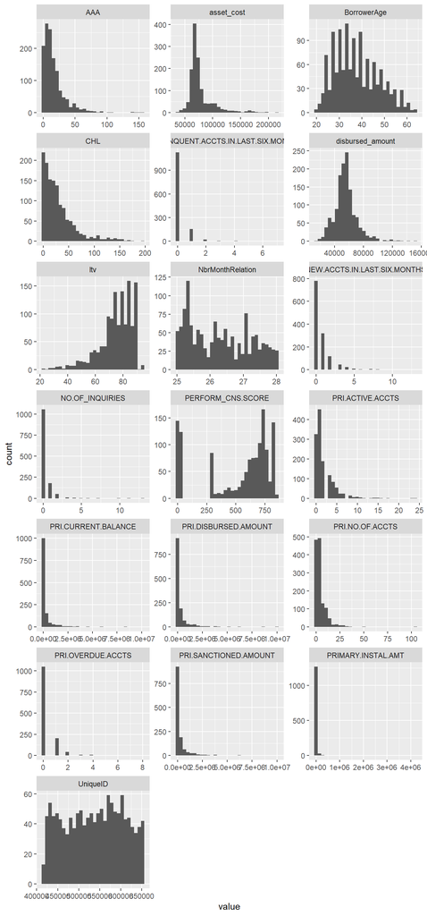

- pour les variables catégorielles:

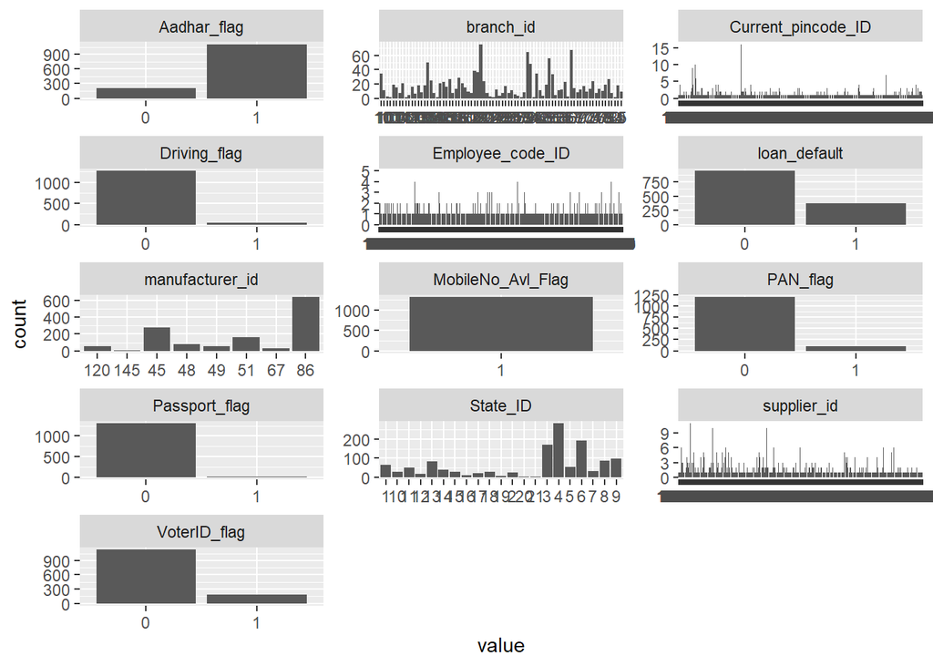

## 4.2 Discussion avec le business

Les modélisateurs doivent revenir avec des questions pour le business et exclure les premières variables

## 4.3 Selection des drivers pour le modèle

### 4.3.1 Analyses univariées

Nous allons étudier une variable souvent révélatrice de la qualité de la saisie de la donnée. L’âge d’un client nous permet de détecter des valeurs fausses ou aberrantes.

```
##    Min. 1st Qu.  Median    Mean 3rd Qu.    Max.
##   20.00   30.00   37.00   37.77   45.00   64.00
```

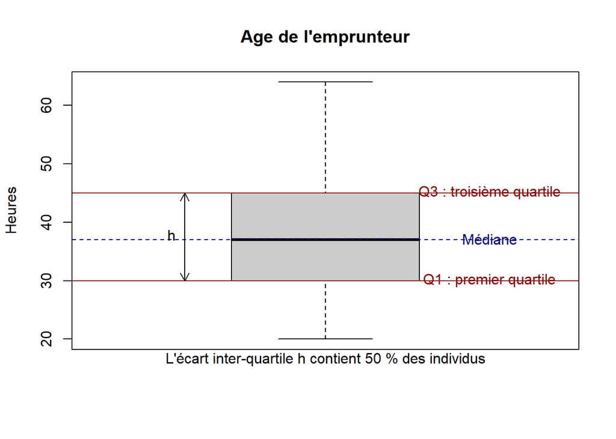

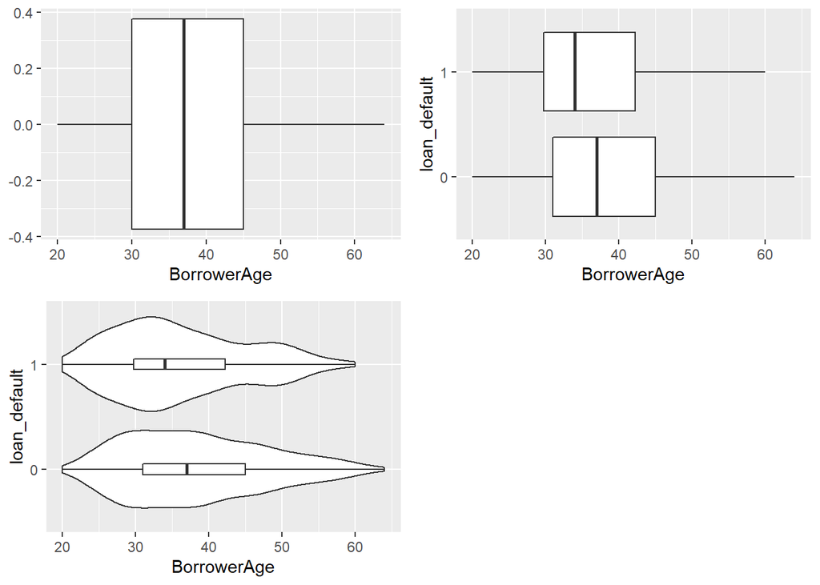

### 4.3.2 Discrétisation des variables

La discrétisation des variables est une pratique courante pour le credit scoring. Elle permet de transformer des variables numériques (âge, ancienneté du client, LTV) en variables catégorielle.

Il est à noter que la discrétisation d’une variable numérique constitue une perte d’information et n’est pas un pré-requis à la regression logistique. Néanmoins, la création de modalités permet souvent une lecture plus simple et une catégorisation des clients.

En discrétisant, nous cherchons le meilleur découpage de la variable à discrétiser vis à vis de notre variable cible. Plusieurs méthodes existent (khi2, WOE, arbres, etc.) mais le principe est toujours le même : commencer par un découpage fin et regrouper les modalités ayant le même taux de défaut.

Nous allons utiliser la fonction woebin du package scorecard. Il découpe sur la base de la mesure WOE ou Weigth of Evidence. Le package fournit également une fonction woebin_plot qui propose des graphiques lisibles des découpages (se limiter à 3).

```
## [INFO] creating woe binning ...
## [INFO] Binning on 1310 rows and 30 columns in 00:00:19
```

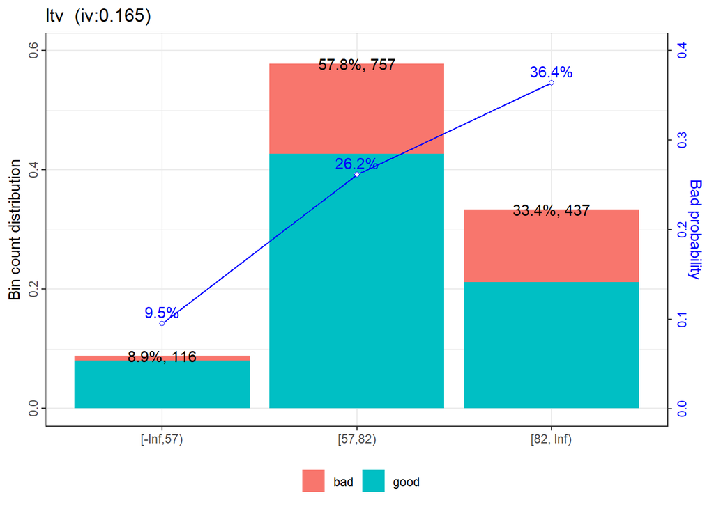

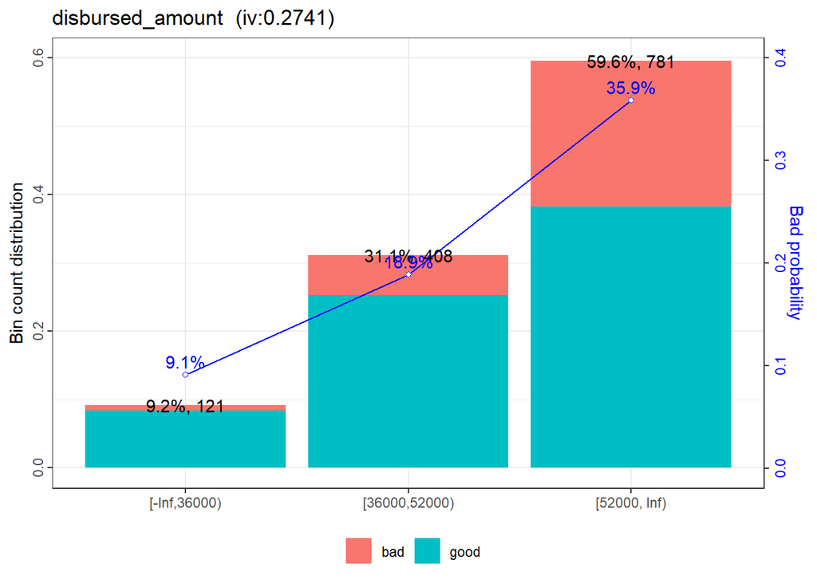

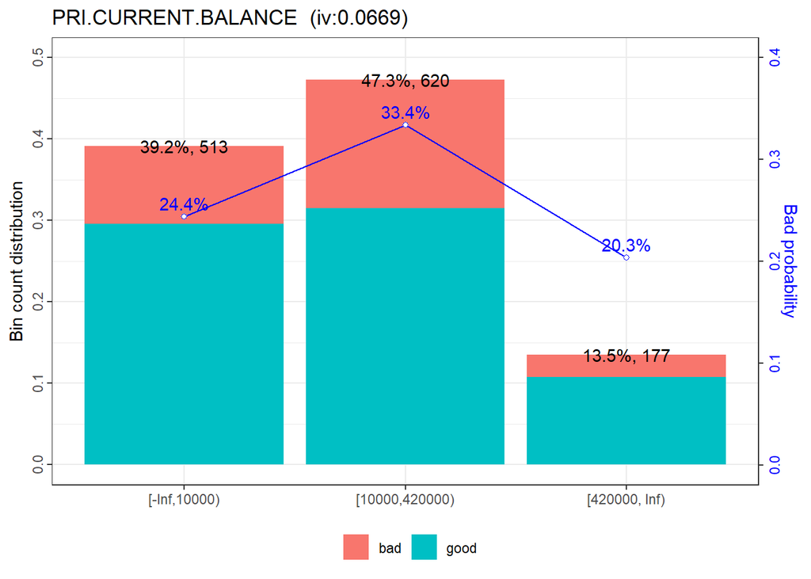

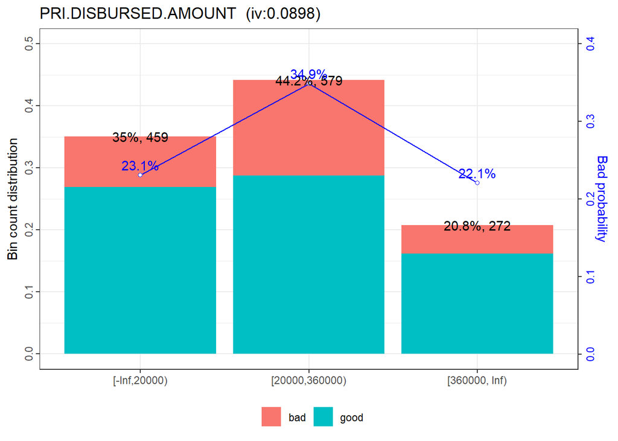

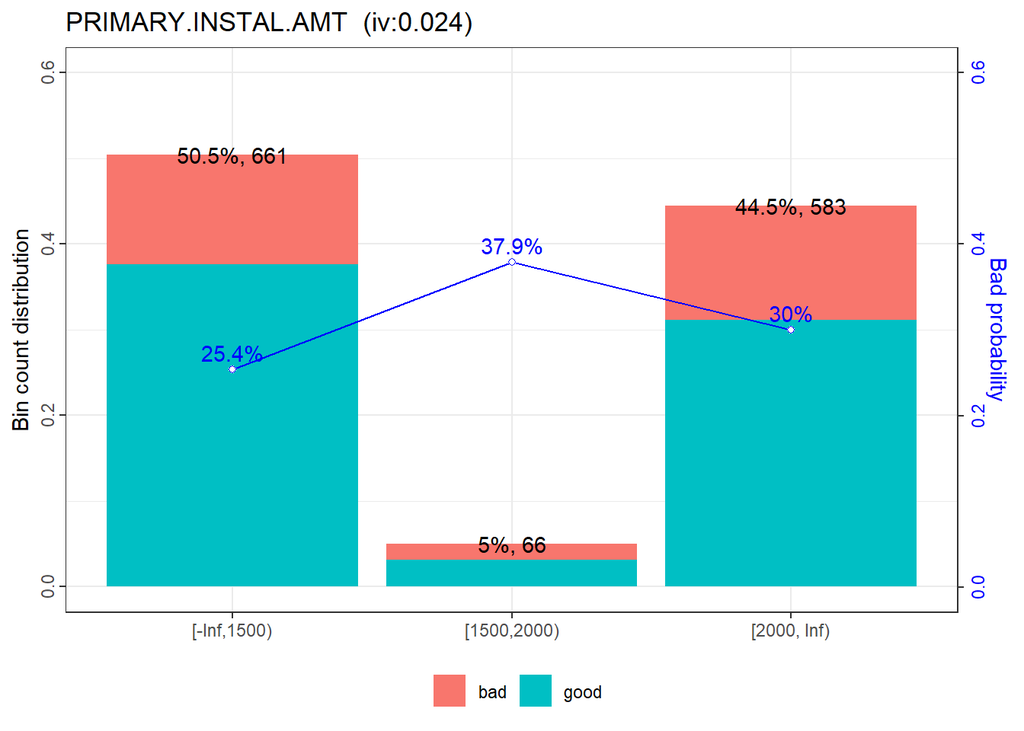

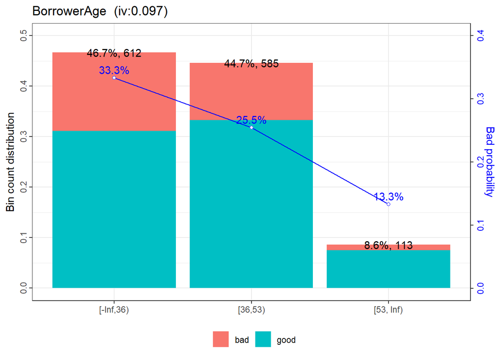

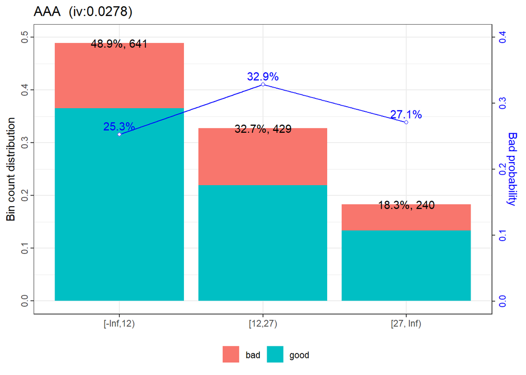

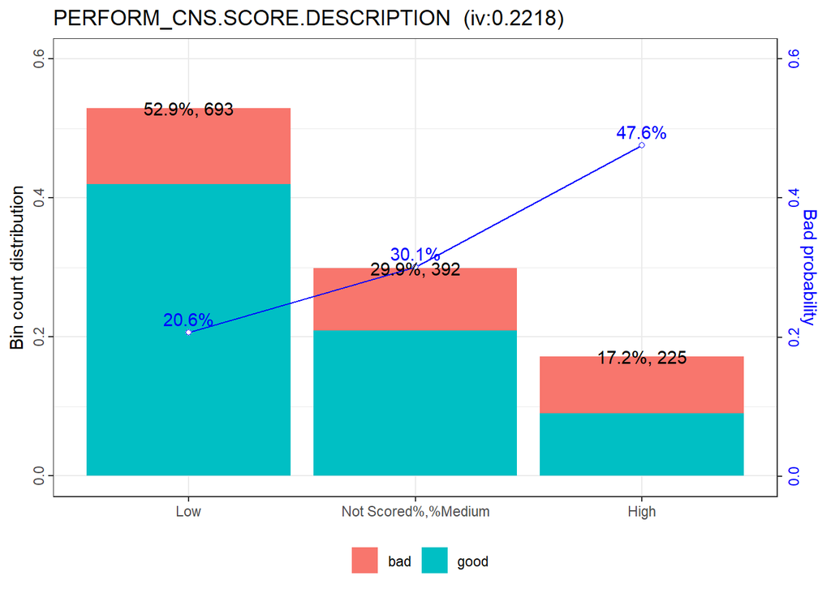

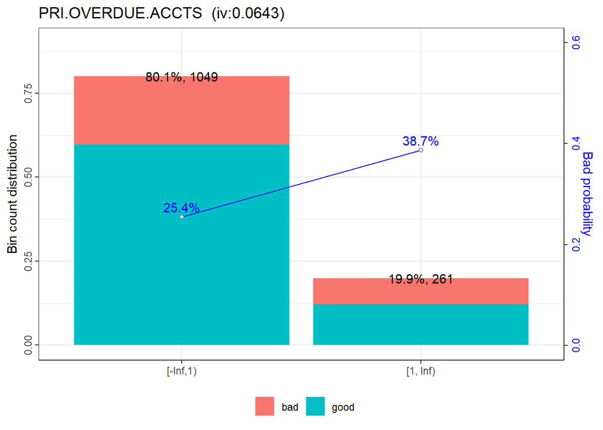

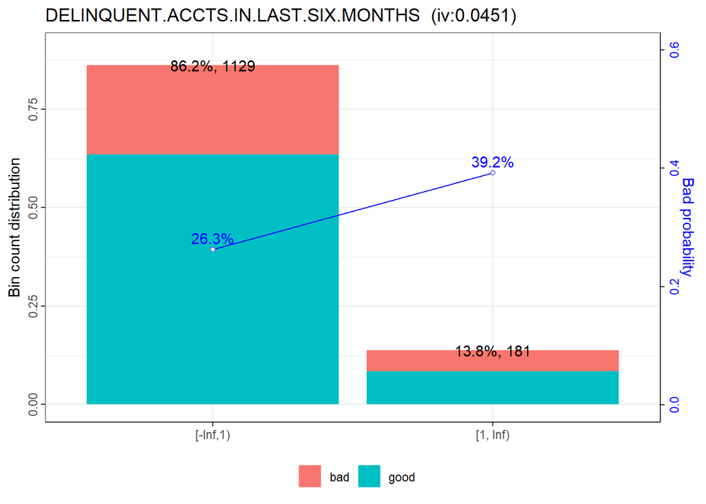

```
## [INFO] converting into woe values ...
```

### 4.3.3 Pouvoir discriminant des variables

Nous pouvons calculer l’information value (IV) pour chaque variable. Cette mesure classique dans le credit scoring permet de mesurer le pouvoir discriminant de chaque variable vis à vis du défaut. Plus l’IV est grand, plus le lien est fort.

| IV | Puissance de la relation |
| --- | --- |
| < 0.02 | très faible |
| 0.02 - 0.1 | faible |
| 0.1 - 0.3 | moyenne |
| 0.3 - 0.5 | forte |
| > 0.5 | très forte |

| variable | info_value |
| --- | --- |
| disbursed_amount_bin | 0.27 |
| PERFORM_CNS.SCORE.DESCRIPTION_bin | 0.22 |
| PERFORM_CNS.SCORE_bin | 0.21 |
| ltv_bin | 0.16 |
| BorrowerAge_bin | 0.10 |
| PRI.DISBURSED.AMOUNT_bin | 0.09 |
| Employment.Type_bin | 0.09 |
| PRI.SANCTIONED.AMOUNT_bin | 0.09 |
| asset_cost_bin | 0.08 |
| PRI.CURRENT.BALANCE_bin | 0.07 |
| PRI.ACTIVE.ACCTS_bin | 0.07 |
| PRI.OVERDUE.ACCTS_bin | 0.06 |
| branch_id_bin | 0.06 |
| NEW.ACCTS.IN.LAST.SIX.MONTHS_bin | 0.06 |
| DELINQUENT.ACCTS.IN.LAST.SIX.MONTHS_bin | 0.04 |
| supplier_id_bin | 0.04 |
| NbrMonthRelation_bin | 0.04 |
| CHL_bin | 0.03 |
| State_ID_bin | 0.03 |
| AAA_bin | 0.03 |
| PRIMARY.INSTAL.AMT_bin | 0.02 |
| manufacturer_id_bin | 0.02 |
| NO.OF_INQUIRIES_bin | 0.02 |
| PRI.NO.OF.ACCTS_bin | 0.01 |
| VoterID_flag_bin | 0.01 |
| Aadhar_flag_bin | 0.01 |
| PAN_flag_bin | 0.00 |

### 4.3.4 Corrélations intra modèle

L’utilisation de variables explicatives corrélées entre elles crée de nombreux biais. Instinctivement, on peut se dire qu’une redondance d’information n’est pas utile dans un modèle (si l’âge du client est discriminant, il n’est pas nécessaire de l’utiliser deux fois, en année et en mois par exemple).

De plus, dans une régression, la corrélation des drivers est un problème qui survient lorsque certaines variables de prévision du modèle mesurent le même phénomène. Une corrélation entre les drivers prononcée s’avère problématique, car elle peut perturber la valeur des coefficients de régression et les rendre instables et difficiles à interpréter. Ce phénomène de surapprentissage n’est pas souhaitable.

Pour ne retenir que les variables pertinentes, une analyse de corrélation est donc nécessaire. L’idée générale est de retenir les variables les plus discriminantes et les moins corrélées entre elles.

Le V de Cramer peut être utilisé en ce sens. Dérivée du khi2, cette mesure normalisée permet de quantifier une “corrélation” entre variables catégorielles :

| Valeurs du V de Cramer (en pct) | Puissance de la relation |
| --- | --- |
| <10 | très faible |
| >10 && <20 | faible |
| >20 && <30 | moyenne |
| >30 | forte |

Le calcul d’une matrice entre les variables d’intérêt permet souvent de séléctionner le meilleur set de variable. Si deux variables sont corrélées entre elles, nous pouvons par exemple ne sélectionner que celle qui est la plus liée avec la variable cible. Ci-dessous un exemple pour quelques variables :

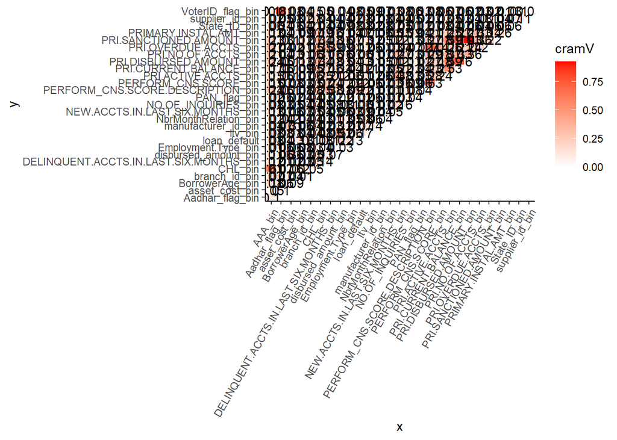

La matrice n’est pas très lisibile car elle embarque toutes les variables. C’est ici que nous devons faire une selection.

Methodologie proposee : on identifie les couples de variable correllees a plus de 30%. Au sein de chaque couple, on ne garde que celle qui est la plus liee au defaut.

| y | x | cramV | correl_def.x | correl_def.y | selection |
| --- | --- | --- | --- | --- | --- |
| CHL_bin | AAA_bin | 0.61 | 0.08 | 0.08 | x |
| disbursed_amount_bin | asset_cost_bin | 0.36 | 0.13 | 0.22 | y |
| ltv_bin | disbursed_amount_bin | 0.52 | 0.22 | 0.17 | x |
| manufacturer_id_bin | asset_cost_bin | 0.31 | 0.13 | 0.07 | x |
| PERFORM_CNS.SCORE.DESCRIPTION_bin | DELINQUENT.ACCTS.IN.LAST.SIX.MONTHS_bin | 0.38 | 0.10 | 0.22 | y |
| PERFORM_CNS.SCORE_bin | PERFORM_CNS.SCORE.DESCRIPTION_bin | 0.63 | 0.22 | 0.20 | x |
| PRI.ACTIVE.ACCTS_bin | NEW.ACCTS.IN.LAST.SIX.MONTHS_bin | 0.38 | 0.09 | 0.11 | y |
| PRI.CURRENT.BALANCE_bin | PRI.ACTIVE.ACCTS_bin | 0.53 | 0.11 | 0.12 | y |
| PRI.DISBURSED.AMOUNT_bin | CHL_bin | 0.34 | 0.08 | 0.13 | y |
| PRI.DISBURSED.AMOUNT_bin | PRI.CURRENT.BALANCE_bin | 0.76 | 0.12 | 0.13 | y |
| PRI.DISBURSED.AMOUNT_bin | PRI.ACTIVE.ACCTS_bin | 0.59 | 0.11 | 0.13 | y |
| PRI.NO.OF.ACCTS_bin | CHL_bin | 0.31 | 0.08 | 0.06 | x |
| PRI.NO.OF.ACCTS_bin | PRI.DISBURSED.AMOUNT_bin | 0.36 | 0.13 | 0.06 | x |
| PRI.NO.OF.ACCTS_bin | PRI.ACTIVE.ACCTS_bin | 0.37 | 0.11 | 0.06 | x |
| PRI.NO.OF.ACCTS_bin | PRI.CURRENT.BALANCE_bin | 0.33 | 0.12 | 0.06 | x |
| PRI.OVERDUE.ACCTS_bin | CHL_bin | 0.35 | 0.08 | 0.12 | y |
| PRI.OVERDUE.ACCTS_bin | DELINQUENT.ACCTS.IN.LAST.SIX.MONTHS_bin | 0.39 | 0.10 | 0.12 | y |
| PRI.OVERDUE.ACCTS_bin | PERFORM_CNS.SCORE_bin | 0.40 | 0.20 | 0.12 | x |
| PRI.OVERDUE.ACCTS_bin | PERFORM_CNS.SCORE.DESCRIPTION_bin | 0.70 | 0.22 | 0.12 | x |
| PRI.SANCTIONED.AMOUNT_bin | CHL_bin | 0.34 | 0.08 | 0.13 | y |
| PRI.SANCTIONED.AMOUNT_bin | PRI.DISBURSED.AMOUNT_bin | 0.93 | 0.13 | 0.13 | x |
| PRI.SANCTIONED.AMOUNT_bin | PRI.NO.OF.ACCTS_bin | 0.36 | 0.06 | 0.13 | y |
| PRI.SANCTIONED.AMOUNT_bin | PRI.ACTIVE.ACCTS_bin | 0.59 | 0.11 | 0.13 | y |
| PRI.SANCTIONED.AMOUNT_bin | PRI.CURRENT.BALANCE_bin | 0.71 | 0.12 | 0.13 | y |
| PRIMARY.INSTAL.AMT_bin | PRI.NO.OF.ACCTS_bin | 0.33 | 0.06 | 0.07 | y |
| VoterID_flag_bin | Aadhar_flag_bin | 0.81 | 0.04 | 0.05 | y |

Après cette séléction, nous pouvons afficher une matrice de correlation allégée :

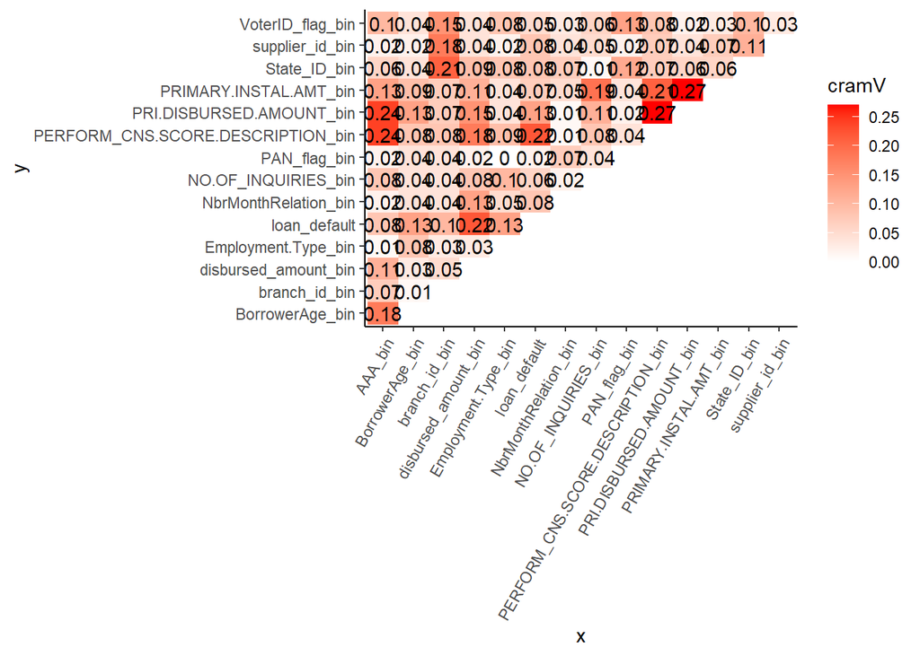

### 4.3.5 Dernières mises en forme

Nous n’avons pas plus d’information sur ces codes. Pour une question d’affichage, nous allons donc fixer leurs modalités à des valeurs génériques (group1, group2, etc.).

## 4.4 La regression logistique

Une fois nos données préparées et nos variables séléctionnées, nous pouvons ajuster une régression logistique (modèle classiquement utilisé).

Pour éviter le surapprentissage, il est toujours bien de séparer votre jeu de données en base d’apprentissage et base de test. Cette dernière base servira de référence pour l’analyse de performance.

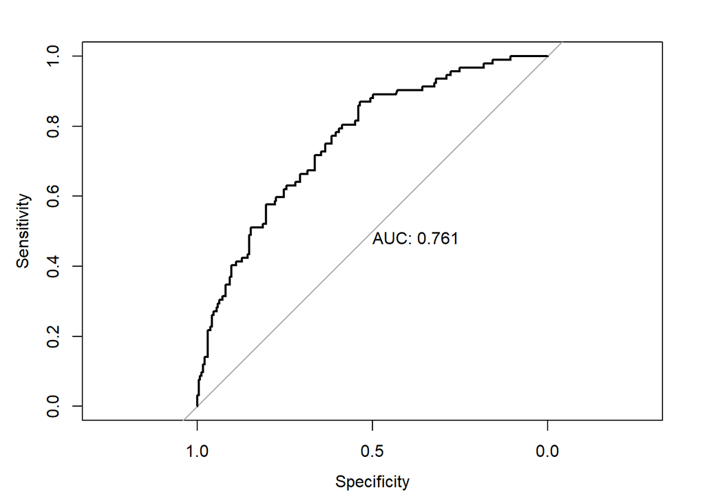

```
##
## Call:
## glm(formula = var_simple_glm, family = binomial(link = "logit"),
##     data = training1_TRAIN)
##
## Deviance Residuals:
##     Min       1Q   Median       3Q      Max
## -1.8934  -0.7880  -0.5233   0.8893   2.7018
##
## Coefficients:
##                                                       Estimate Std. Error
## (Intercept)                                          -2.250191   0.487083
## disbursed_amount_bin[36000,52000)                     0.832290   0.400207
## disbursed_amount_bin[52000, Inf)                      1.563565   0.380517
## branch_id_binbranch_group2                           -0.776150   0.375150
## branch_id_binbranch_group3                            0.085942   0.195965
## supplier_id_binsupplier_group2                       -0.550631   0.383904
## supplier_id_binsupplier_group3                        0.302787   0.187712
## Employment.Type_binSelf employed%,%None               0.717929   0.166992
## State_ID_binstate_group2                              0.004425   0.248069
## State_ID_binstate_group3                              0.235797   0.177876
## PAN_flag_bin1                                        -0.526681   0.315308
## VoterID_flag_bin1                                     0.443895   0.231747
## PERFORM_CNS.SCORE.DESCRIPTION_binLow                 -1.354110   0.217909
## PERFORM_CNS.SCORE.DESCRIPTION_binNot Scored%,%Medium -0.618066   0.252105
## PRI.DISBURSED.AMOUNT_bin[20000,360000)                0.462811   0.201779
## PRI.DISBURSED.AMOUNT_bin[360000, Inf)                -0.063303   0.264583
## PRIMARY.INSTAL.AMT_bin[1500,2000)                     0.825271   0.369044
## PRIMARY.INSTAL.AMT_bin[2000, Inf)                     0.277066   0.185341
## NO.OF_INQUIRIES_bin[1,2)                              0.041686   0.231361
## NO.OF_INQUIRIES_bin[2, Inf)                           0.333704   0.309743
## AAA_bin[12,27)                                        0.406989   0.193328
## AAA_bin[27, Inf)                                      0.215989   0.243619
## BorrowerAge_bin[36,53)                               -0.557233   0.169914
## BorrowerAge_bin[53, Inf)                             -1.431511   0.366951
## NbrMonthRelation_bin[26.9,27.25)                     -0.548925   0.303426
## NbrMonthRelation_bin[27.25, Inf)                      0.100415   0.200757
##                                                      z value Pr(>|z|)
## (Intercept)                                           -4.620 3.84e-06 ***
## disbursed_amount_bin[36000,52000)                      2.080  0.03756 *
```

[output cut: 19 more lines]

```
## AAA_bin[27, Inf)                                       0.887  0.37530
## BorrowerAge_bin[36,53)                                -3.279  0.00104 **
## BorrowerAge_bin[53, Inf)                              -3.901 9.58e-05 ***
## NbrMonthRelation_bin[26.9,27.25)                      -1.809  0.07044 .
## NbrMonthRelation_bin[27.25, Inf)                       0.500  0.61695
## ---
## Signif. codes:  0 '***' 0.001 '**' 0.01 '*' 0.05 '.' 0.1 ' ' 1
##
## (Dispersion parameter for binomial family taken to be 1)
##
##     Null deviance: 1167.18  on 982  degrees of freedom
## Residual deviance:  987.79  on 957  degrees of freedom
## AIC: 1039.8
##
## Number of Fisher Scoring iterations: 5
```

Remarque : des coefficients de la regression logistique ne sont pas significativement non nuls. Dans cette situation, il faudrait soit exclure la variable, soit revoir sa discrétisation jusqu’à avoir des coefficients tous significatifs

Graphiquement, on peut observer la distribution des scores selon le fait que le client soit tombé en défaut ou non :

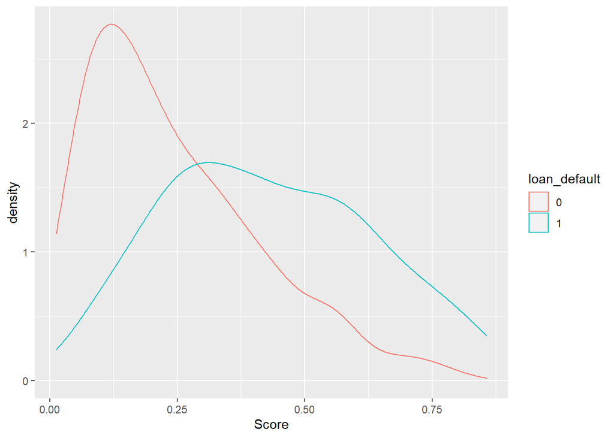

Comme attendu, les scores des clients tombant en défaut sont distribués dans les valeurs plus élevées. En effet, la régression logistique ajuste la probabilité d’avoir loan_default=1 en fonction des variables séléctionnées.

# 5 Quantification de la probabilité de défaut

N.B : cette partie est indépendante de la partie précédente (construction d’un score).

## 5.1 Données et contexte

Supposons qu’un score a été construit et qu’en sortie, quatre classes de risque sont proposées.

La quantification consiste à attribuer une probabilité de défaut à chaque classe, si tant est que celles-ci soient correctement définies ! Dans cette partie, nous allons voir les faiblesses potentielles d’une échelle et calibrer une probabilité de défaut pour chaque classe.

Le jeu de données (indépendant de la partie scoring) se présente sous la forme de quatres séries temporelles de taux de défaut en pourcentage et qautre séries d’effectif.

Data summary

| Name | dataquant |
| --- | --- |
| Number of rows | 32 |
| Number of columns | 9 |
| _______________________ |  |
| Column type frequency: |  |
| character | 1 |
| numeric | 8 |
| ________________________ |  |
| Group variables | None |

**Variable type: character**

| skim_variable | n_missing | complete_rate | min | max | empty | n_unique | whitespace |
| --- | --- | --- | --- | --- | --- | --- | --- |
| Date | 0 | 1 | 10 | 10 | 0 | 32 | 0 |

**Variable type: numeric**

| skim_variable | n_missing | complete_rate | mean | sd | p0 | p25 | p50 | p75 | p100 | hist |
| --- | --- | --- | --- | --- | --- | --- | --- | --- | --- | --- |
| ODR_CR1 | 0 | 1 | 1.52 | 0.33 | 1.03 | 1.22 | 1.48 | 1.84 | 2.00 | ▇▅▅▃▇ |
| ODR_CR2 | 0 | 1 | 1.72 | 0.31 | 1.22 | 1.47 | 1.63 | 1.98 | 2.18 | ▆▇▃▇▇ |
| ODR_CR3 | 0 | 1 | 3.75 | 0.47 | 3.07 | 3.33 | 3.71 | 4.17 | 4.58 | ▇▃▆▂▆ |
| ODR_CR4 | 0 | 1 | 8.05 | 0.95 | 6.35 | 7.22 | 8.16 | 8.56 | 9.85 | ▃▂▇▃▂ |
| NB_CR1 | 0 | 1 | 1242.59 | 128.80 | 1026.00 | 1100.75 | 1264.50 | 1347.25 | 1453.00 | ▇▂▇▇▅ |
| NB_CR2 | 0 | 1 | 745.47 | 29.82 | 704.00 | 717.00 | 741.50 | 765.50 | 800.00 | ▇▇▅▃▅ |
| NB_CR3 | 0 | 1 | 550.09 | 28.78 | 501.00 | 525.00 | 545.00 | 576.00 | 600.00 | ▅▇▃▇▅ |
| NB_CR4 | 0 | 1 | 125.81 | 14.78 | 100.00 | 114.75 | 126.00 | 140.25 | 146.00 | ▅▃▆▃▇ |

## 5.2 Tracé des séries temporelles

Dans un premier temps, il est toujours utile d’observer graphiquement les séries de taux défaut. On identifie ainsi les potentiels problèmes :

- D’hétérogénéité : les classes ont été mal définies car ne traduisent pas une hiérarchie du risque
- D’homogénéité : une volatilité forte d’une série signfie que les clients/contrats de cette classe ont des taux de défaut instables
- D’estimation : ne pas perdre de vue qu’une simple moyenne arithmétique + des marges de conservatismes constituerons la probabilité de défaut. Il faut donc identifier tout élément pouvant biaiser la valeur d’une moyenne.

D’ailleurs, quel est le danger lorsqu’on résume une information à sa moyenne ?

Le tracé des séries temporelles peut se faire avec le package ggplot :

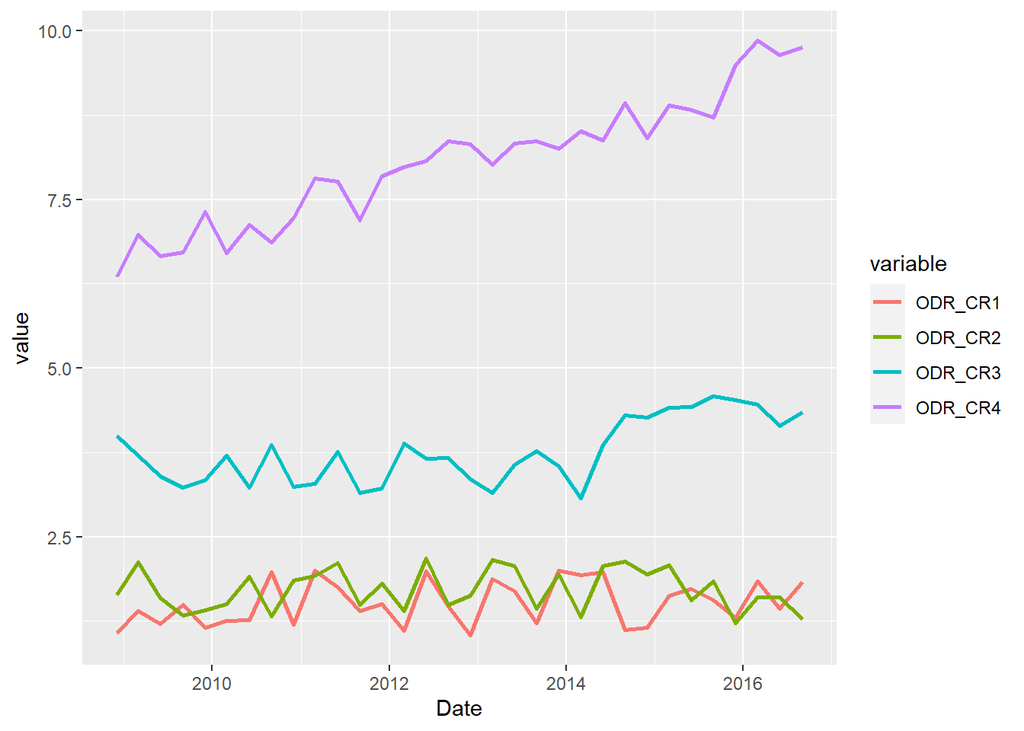

Observons les séries une par une :

- Des classes meriteraient elles d’être regroupées ?
- Qu’observez-vous sur la troisième classe en début 2014 ? Quel est le danger en prenant la moyenne des taux de défaut ? Comment couvrir ce risque ?
- Quel comportement de la quatrième classe présuppose d’un traitement spécifique pour son calibrage ? Que proposeriez-vous ?

## 5.3 Remédiation des points identfiés

### 5.3.1 Mise en forme des donnees

En amont, revoyons le format des données : nous allons les mettre en format “long” plutôt qu’en format “wide”. C’est une transformation que nous avons déjà faite pour faciliter le tracé du graphique des séries temporelles.

```
##         Date Classe      ODR   NB
## 1 2008-12-01    CR1 1.074886 1081
## 2 2008-12-01    CR2 1.632870  733
## 3 2008-12-01    CR3 3.993415  527
## 4 2008-12-01    CR4 6.354301  143
## 5 2009-03-01    CR1 1.399839 1306
## 6 2009-03-01    CR2 2.126456  741
```

### 5.3.2 Traitement des classes 1 et 2

Nous pouvons dans un premier temps regrouper les classes 1 et 2

[output not shown]

### 5.3.3 Traitement de la nouvelle classe 2

Notons ensuite que la classe 3 montre un changement de régime début 2014. Pour assurer le conservatisme de la PD calibrée nous pouvons par exemple surpondérer les trois dernières années (de 2014 à 2016). Nous avons 32 dates en tout, dont 11 comprises dans la periode à surpondérer. Par exemple, nous pouvons doubler leur poids.

### 5.3.4 Traitement de la tendance de la classe 3

Pour la classe 3, nous devons prendre en compte la tendance de la série. Une méthode simple consisterait à ajuster une régression linéaire du taux de défaut en fonction du temps, en omettant les derniers points de la courbe pour identifier l’écart potentiel que génèrerai cette tendance.

Retraçons la courbe de la classe 3 :

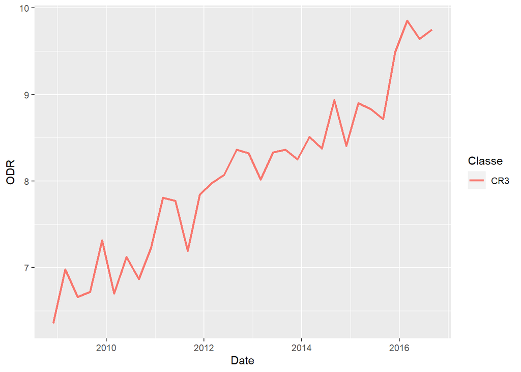

Méthodologie proposée : nous allons ajuster une regression lineaire sur les 20 premiers points de la courbe. La marge de conservatisme correspondra à la moyenne des différences positives entre les taux de défaut prédits par cette regression sur les 12 derniers points et les valeurs observées.

```
## # A tibble: 6 x 7
## # Groups:   Date, Classe [6]
##   Date       Classe   ODR    NB poids annee temps
##   <date>     <fct>  <dbl> <int> <dbl> <dbl> <int>
## 1 2008-12-01 CR3     6.35   143     1  2008     1
## 2 2009-03-01 CR3     6.98   128     1  2009     2
## 3 2009-06-01 CR3     6.66   139     1  2009     3
## 4 2009-09-01 CR3     6.72   123     1  2009     4
## 5 2009-12-01 CR3     7.32   121     1  2009     5
## 6 2010-03-01 CR3     6.70   145     1  2010     6
```

```
##
## Call:
## lm(formula = ODR ~ temps, data = datareg)
##
## Residuals:
##      Min       1Q   Median       3Q      Max
## -0.45955 -0.13209 -0.03165  0.17012  0.38231
##
## Coefficients:
##             Estimate Std. Error t value Pr(>|t|)
## (Intercept)  6.41912    0.12005   53.47  < 2e-16 ***
## temps        0.10300    0.01002   10.28 5.85e-09 ***
## ---
## Signif. codes:  0 '***' 0.001 '**' 0.01 '*' 0.05 '.' 0.1 ' ' 1
##
## Residual standard error: 0.2584 on 18 degrees of freedom
## Multiple R-squared:  0.8544, Adjusted R-squared:  0.8463
## F-statistic: 105.6 on 1 and 18 DF,  p-value: 5.849e-09
```

```
## [1] 0.3790629
```

## 5.4 Marge d’estimation

La marge d’estimation couvre l’erreur d’estimation liée à la moyenne des taux de défaut (dépend du nombre de points à disposition, au nombre de clients ayant permis d’estimer le taux de défaut et à la volatilité du taux de défaut). Classiquement, l’intervalle de confiance d’une moyenne historique de taux de défaut considérés indépendants entre deux dates s’écrit :

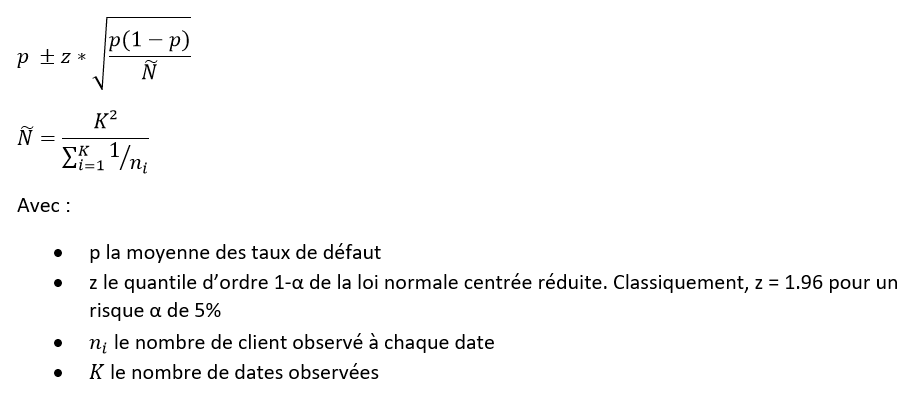

Après le calibrage d’une probabilité de défaut, il est toujours nécessaire de vérifier graphiquement que nos valeurs calibrées couvrent bien les taux observés :

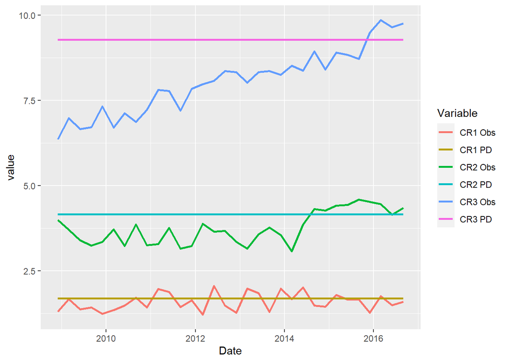

Vous noterez que les valeurs de PD des classes 2 et 3 manquent encore de prudence. Avant que la BCE ne vous tape sur les doigts, vous devriez y remédier !